# Algorithmique Projet: SMO and SGD algorithm in SVM classification - M2DS

### Do Thanh Dat LE, Piseth KHENG

#### Evry University, Paris-Saclay University

### April 10, 2024

## Testing Algorithms

```r
library(SVMalgo)
library(microbenchmark)
```

```r
library(ggplot2)
```

We simulate a linearly separable data set. The input data was random uniform m-dimensional vectors. A m-dimensional weight vector was generated randomly in [-10,10]. If the dot product of the weight with an input point is greater than 0, then a positive label 1 is assigned to the input point. If the dot product is less than 0, then a negative label -1 is assigned.

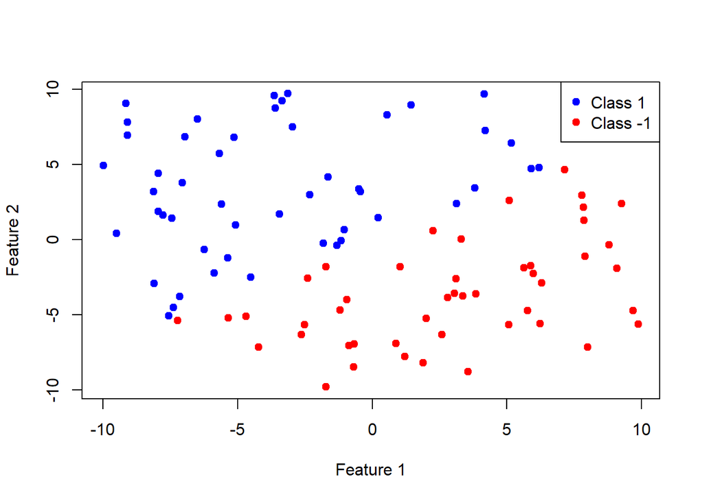

```r
linearly_separable_data <- function(n_samples, n_features, noise = 0) {
  # Generate random coefficients for the linear equation
  coefficients <- runif(n_features, -10, 10)

  # Generate random data points
  X <- matrix(runif(n_samples * n_features, -10, 10), ncol = n_features)

  # Compute the target variable (labels) based on the linear equation
  y <- ifelse(X %*% coefficients > 0, 1, -1)

  # Add noise if specified
  if (noise > 0) {
    y <- y * rnorm(length(y), mean = 1, sd = noise)
  }

  # Return the data
  return(list(X = X, y = y))
}

# Example usage:
set.seed(123)  # for reproducibility
data <- linearly_separable_data(n_samples = 100, n_features = 2, noise = 0)

# Plot the data
plot(data$X, col = ifelse(data$y > 0, "blue", "red"), pch = 19, xlab = "Feature 1", ylab = "Feature 2")
legend("topright", legend = c("Class 1", "Class -1"), col = c("blue", "red"), pch = 19)
```

We define a function `one.simu` to simplify the simulation study for time complexity.

```r
one.simu <- function(n, num_features = 10, type = "sample", func = "svm_smo")
{
  set.seed(123)
  if(type == "sample"){data <- linearly_separable_data(n, num_features)}
  if(func == "svm_smo"){t <- system.time(svm_smo(data$X, data$y, C = 1, tol = 1e-3, max_passes = 1, kernel_fun = linear_kernel))[[1]]}
  if(func == "svm_sgd"){t <- system.time(svm_sgd(data$X, data$y, epochs = 100, C = 1, learning_rate = 1e-2, tolerance = 1e-3))[[1]]}
  if(func == "svm_smo_Rcpp"){t <- system.time(svm_smo_Rcpp(data$X, data$y, C = 1, tol = 1e-3, max_passes = 1))[[1]]}
  if(func == "svm_sgd_Rcpp"){t <- system.time(svm_sgd_Rcpp(data$X, data$y, epochs = 100, C = 1, learning_rate = 1e-2, tolerance = 1e-3))[[1]]}
  return(t)
}
```

First, we evaluate the running time of the algorithms on the simulated data with the size of 1000 observations and only 2 features (the simplest case).

```r
n <- 1000
```

and we get:

```r
one.simu(n, num_features = 2, func = "svm_smo")
```

```
## [1] 1.62
```

```r
one.simu(n, num_features = 2, func = "svm_sgd")
```

```
## [1] 0.05
```

```r
one.simu(n, num_features = 2, func = "svm_smo_Rcpp")
```

```
## [1] 0.65
```

```r
one.simu(n, num_features = 2, func = "svm_sgd_Rcpp")
```

```
## [1] 0
```

The Rcpp is faster than R in both SMO and SGD.

### Comparisons

we compare the running time with repeated executions (`nbSimus` times)

```r
nbSimus <- 10
time1 <- 0; time2 <- 0; time3 <- 0; time4 <- 0

for(i in 1:nbSimus){time1 <- time1 + one.simu(n, num_features = 2, func = "svm_smo")}
for(i in 1:nbSimus){time2 <- time2 + one.simu(n, num_features = 2, func = "svm_sgd")}
for(i in 1:nbSimus){time3 <- time3 + one.simu(n, num_features = 2, func = "svm_smo_Rcpp")}
for(i in 1:nbSimus){time4 <- time4 + one.simu(n, num_features = 2, func = "svm_sgd_Rcpp")}
```

```r
#gain R -> Rcpp
time1/time3
```

```
## [1] 2.008237
```

```r
time2/time4
```

```
## [1] 9.333333
```

Rcpp is faster than R for our 2 algorithms.

```r
#gain smo -> sgd
time1/time2
```

```
## [1] 43.53571
```

```r
time3/time4
```

```
## [1] 202.3333
```

With the data length of `1000` and 2 features, SGD runs faster than SMO.

```r
#max gain
time1/time4
```

```
## [1] 406.3333
```

## Microblenchmark

We compare `svm_smo_Rcpp` with `svm_sgd_Rcpp` for data lengths `n = 1000` and with only 2 features.

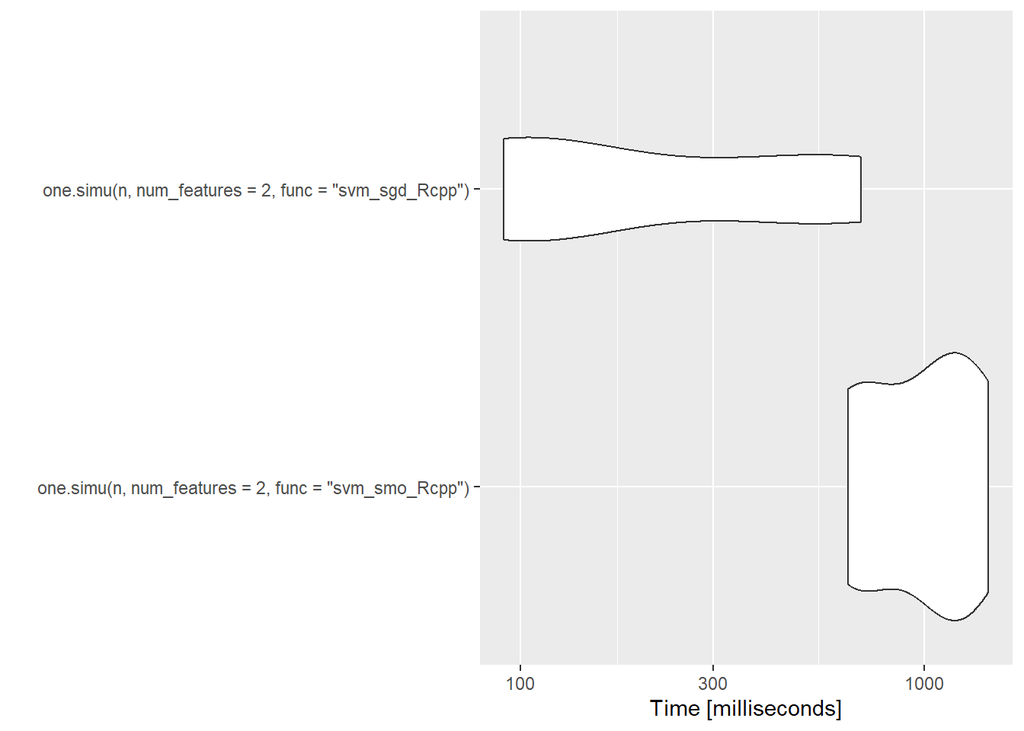

```r
n <- 1000
res <- microbenchmark(one.simu(n, num_features = 2, func = "svm_smo_Rcpp"), one.simu(n, num_features = 2, func = "svm_sgd_Rcpp"), times = 5)
autoplot(res)
```

```r
res
```

```
## Unit: milliseconds
##                                                  expr      min       lq
##  one.simu(n, num_features = 2, func = "svm_smo_Rcpp") 649.3084 707.5911
##  one.simu(n, num_features = 2, func = "svm_sgd_Rcpp")  90.9001 101.1078
##       mean    median        uq       max neval
##  1016.2229 1138.6147 1142.6336 1442.9668     5
##   300.6327  112.3601  502.4334  696.3619     5
```

At this data length `1000` and only 2 features, we have a robust difference in running time between SMO_Rcpp and SGD_Rcpp.